# ModelosII

## TERMINOS GENERALES

### Matriz de confusión

- Una matriz de confusión es una tabla que se usa a menudo para describir el rendimiento de un modelo de clasificación sobre en un conjunto de datos de prueba para los cuales se conocen los valores verdaderos.
- Definamos ahora los términos más básicos para nuestro estudio:
  - Verdaderos Positivos (TP): estos son casos en los que predijimos que sí (van a fallecer), y sí fallecen.
  - Verdaderos Negativos (TN): Predijimos que no iban a fallecer, y los pacientes no fallecen.
  - Falsos Positivos (FP): Predijimos que sí iban a fallecer, pero en realidad no han fallecido.
  - Falsos Negativos (FN): Predijimos que no, pero en realidad tienen la enfermedad.
- En nuestro estudio se ha tomado como positivo, el valor de “F”, es decir, que el paciente fallezca.
- Otra información a tener en cuenta en los siguientes graficos:
  - Reference V, Prediction V -> Verdaderos Negativos (TN).
  - Reference F, Prediction V -> Falsos Negativos (FN)
  - Reference V, Prediction F -> Falsos Positivos (FP)
  - Reference F, Prediction F -> Verdaderos Positivos (TP)
- Estimadores de mejora
  - Para modelos de regresion
  - R2
  - Root mean Square error
  - Correlación de Spearman
  - Para modelos de clasificacion
  - Overall Accuracy
  - Kappa Statistics
  - Sensibilidad: nos indica la capacidad de nuestro estimador para dar como casos positivos los casos realmente positivos.Proporcion de fallecidos correctamente identificados. Si predice que fallece, entonces que realmente fallezca. +Especificidad:nos indica la capacidad de nuestro estimador para dar como casos negativos los casos realmente negativos (que los usuarios esten vivos); proporción de vivos correctamente identificados.

### OVERFITTING

- El overfitting, tambien llamado sobreajuste: es el efecto que se da al entrenar de mas un algoritmo de aprendizaje, de este modo el algoritmo queda muy ajustado a caracteristicas muy especificas y por lo tanto, su respuesta a nuevos datos empeora.
- Existen distintas tecnicas para evitar el sobreajuste:
- Cross-Validation: esta técnica consiste en dividir los datos en varios conjuntos de datos y luego elegir uno de los conjuntos para medir la precisión de la predicción “test” y el resto para entrenar.Concretamente se divide la muestra en K submuestras, de forma que se utilizan K-1 para estimar el modelo y la restante como submuestra de evaluación, este proceso se repite K veces, de forma que cada submuestra es utilizada una vez para evaluar el modelo y K-1 veces para el ajuste.
- Detención temprana: proporciona información sobre cuántas iteraciones se pueden ejecutar antes de que el algoritmo de aprendizaje comience a sobrepasar el límite.
- Poda: Simplemente elimina los nodos que agregan poca capacidad de predicción para el problema en cuestión.
- Regularización: introduce un término de costo a la hora de obtener más variables con la función objetivo. Intenta reducir a cero los coeficientes de muchas variables consiguiendo asi reducir el término de costo.
- https://www.r-project.org/conferences/useR-2013/Tutorials/kuhn/user_caret_2up.pdf

## REGRESION LOGISTICA

### Usando todos los predictores

- En primer lugar vamos a construir nuestro modelo de regresion logistica con los datos de entrenamiento.

```
##
## Call:
## NULL
##
## Deviance Residuals:
##     Min       1Q   Median       3Q      Max
## -2.6212  -0.7896   0.4030   0.7663   2.7535
##
## Coefficients:
##              Estimate Std. Error z value Pr(>|z|)
## (Intercept) -5.025051   0.369242 -13.609  < 2e-16 ***
## sex         -0.088864   0.094387  -0.941 0.346456
## age         -0.042629   0.002311 -18.445  < 2e-16 ***
## cause       -0.011517   0.047834  -0.241 0.809739
## ec           0.437707   0.083247   5.258 1.46e-07 ***
## eye          0.273820   0.046107   5.939 2.87e-09 ***
## motor        0.261235   0.030660   8.520  < 2e-16 ***
## verbal       0.208675   0.038848   5.372 7.81e-08 ***
## pupils      -0.352803   0.051024  -6.914 4.70e-12 ***
## phm          0.460228   0.077954   5.904 3.55e-09 ***
## sah          0.261974   0.077846   3.365 0.000765 ***
## oblt         0.601150   0.088771   6.772 1.27e-11 ***
## mdls         0.819740   0.110993   7.386 1.52e-13 ***
## hmt          0.440056   0.080109   5.493 3.95e-08 ***
## ---
## Signif. codes:  0 '***' 0.001 '**' 0.01 '*' 0.05 '.' 0.1 ' ' 1
##
## (Dispersion parameter for binomial family taken to be 1)
##
##     Null deviance: 6601.0  on 4889  degrees of freedom
## Residual deviance: 4774.3  on 4876  degrees of freedom
## AIC: 4802.3
##
## Number of Fisher Scoring iterations: 4
```

- Una vez hecho esto, vamos a utilizar los datos de test para predecir el modelo que hemos construido y comprobaremos el ajuste de este.

```
## Confusion Matrix and Statistics
##
##           Reference
## Prediction    F    V
##          F  546  191
##          V  303 1056
##
##                Accuracy : 0.7643
##                  95% CI : (0.7455, 0.7823)
##     No Information Rate : 0.5949
##     P-Value [Acc > NIR] : < 2.2e-16
##
##                   Kappa : 0.5005
##  Mcnemar's Test P-Value : 5.91e-07
##
##             Sensitivity : 0.6431
##             Specificity : 0.8468
##          Pos Pred Value : 0.7408
##          Neg Pred Value : 0.7770
##              Prevalence : 0.4051
##          Detection Rate : 0.2605
##    Detection Prevalence : 0.3516
##       Balanced Accuracy : 0.7450
##
##        'Positive' Class : F
##
```

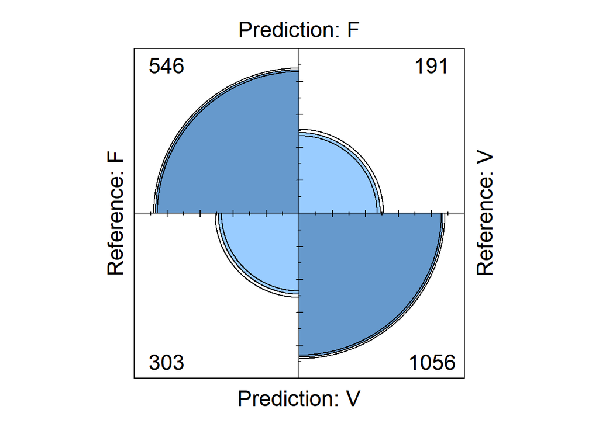

- Como podemos comprobar, el modelo se ajusta bastante bien, con un 76%. Dicho de otra forma, el modelo es capaz de predecir correctamente un 76% de los datos de los pacientes.
- A continuacion, vamos a utilizar la curva de ROC con los valores de pAUC:

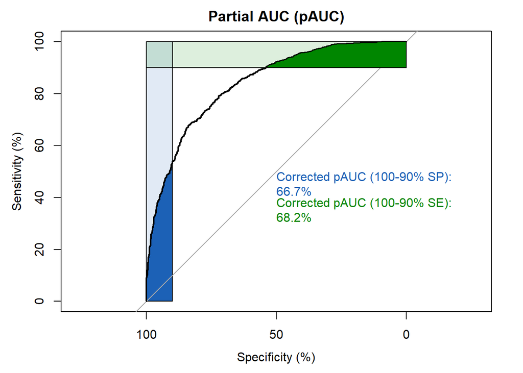

### Eliminando los predictores “sex” y “cause”"

- Al igual que hicimos en el modelo anterior, vamos a construir el modelo eliminando las variables de “sex” y “cause”
- Una vez hecho esto, vamos a utilizar los datos de test para predecir el modelo que hemos construido y comprobaremos el ajuste de este.

```
## Confusion Matrix and Statistics
##
##           Reference
## Prediction    F    V
##          F  543  191
##          V  306 1056
##
##                Accuracy : 0.7629
##                  95% CI : (0.7441, 0.781)
##     No Information Rate : 0.5949
##     P-Value [Acc > NIR] : < 2.2e-16
##
##                   Kappa : 0.4972
##  Mcnemar's Test P-Value : 3.161e-07
##
##             Sensitivity : 0.6396
##             Specificity : 0.8468
##          Pos Pred Value : 0.7398
##          Neg Pred Value : 0.7753
##              Prevalence : 0.4051
##          Detection Rate : 0.2591
##    Detection Prevalence : 0.3502
##       Balanced Accuracy : 0.7432
##
##        'Positive' Class : F
##
```

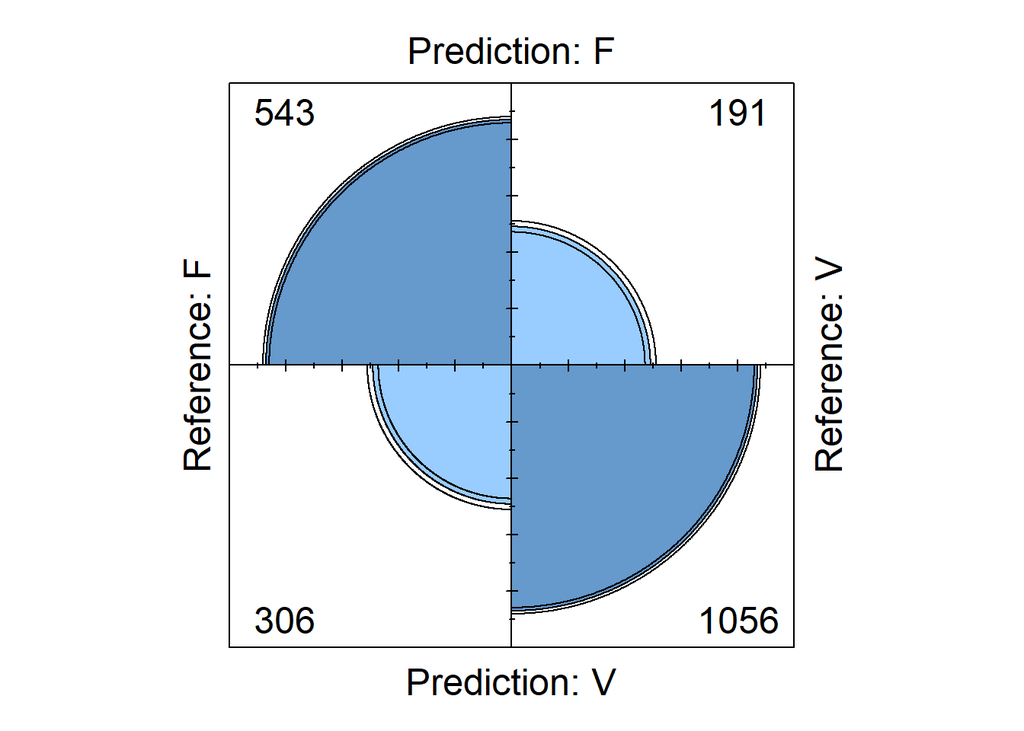

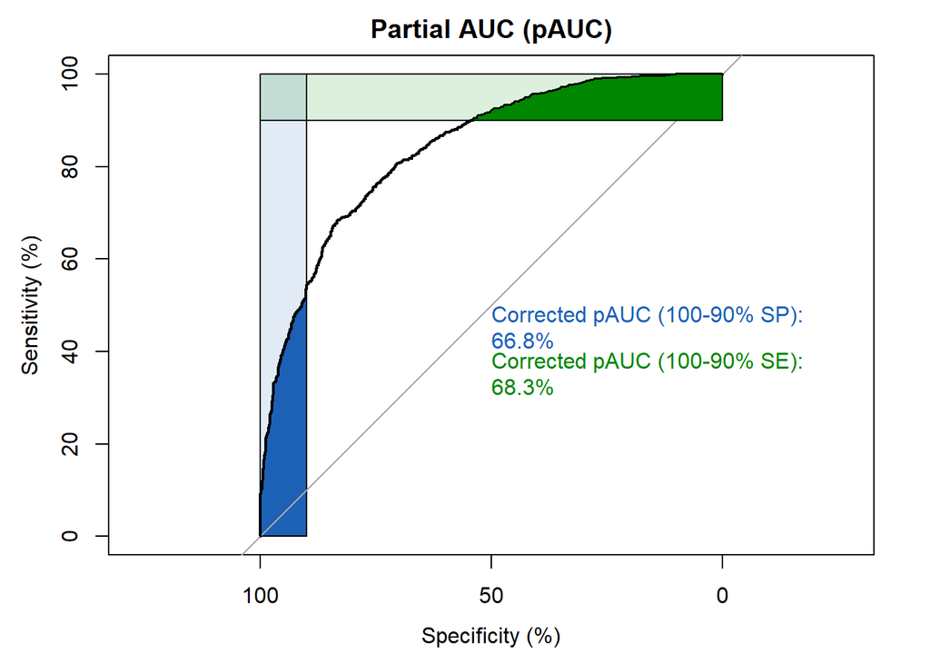

## NAIVES BAYES

*Las redes bayesianas, junto con los árboles de decisión y las redes neuronales artificiales, han sido los tres métodos más usados en aprendizaje automático durante estos últimos años en tareas como la clasificación.

- La idea de Naïve Bayes es sencilla y es usar las probabilidades condicionales de los valores de una variable para determinar a qué categoría pertenece, estas probabilidades se calculan con el teorema de Bayes.
- Por ejemplo, si quisieramos clasificar la valoracion de un determinado servicio, podriamos hacerlo en dos categorias, “positiva” y “negativa”; de esta forma, tenemos que determinar que palabras son mas probables de encontrar en cada una de estas categorias. Se puede intuir que es mas probable que una valoracion pertenezca a la categoria “positiva”, si los valores son “bueno” o “excelente” y menos probable si contiene palabras como “malo” o “deficiente”.

*Por tanto, deberemos obtener la probabilidad de que una valoracion pertenezca a la categoria “positiva”, dado que la valoracion contiene la palabra “excelente”. Por tanto deberiamos calcular p(positiva|excelente)

- Debido a que este algoritmo calcula las probabilidades de cada valor por separado, como si los valores fueran independientes unos de otros, se conoce como “ingenuo”. Lo que se hace, por lo tanto, es calcular la probabilidad condicional de cada valor, asumiendo de forma “ingenua”, que en esta probabilidad no importa cuales valores de variables lo acompañan en cada registro.
- En este caso, tambien vamos a utilizar el paquete de caret para realizar el entrenamiento del modelo. Utilizaremos tambien la validacion cruzada con 10 iteraciones.
- Los parametros con los que hemos hecho la fuerza bruta ha sido los siguientes:
- useKernel: tipo de distribucion
- fL: la corrección de Laplace
- adjust: Ajuste de ancho de banda

```
## Naive Bayes
##
## 4890 samples
##   13 predictor
##    2 classes: 'F', 'V'
##
## No pre-processing
## Resampling: Cross-Validated (10 fold)
## Summary of sample sizes: 4401, 4401, 4401, 4401, 4401, 4401, ...
## Resampling results across tuning parameters:
##
##   usekernel  fL  adjust  Accuracy   Kappa
##   FALSE      0   0       0.7398773  0.4562820
##   FALSE      0   1       0.7398773  0.4562820
##   FALSE      0   2       0.7398773  0.4562820
##   FALSE      1   0       0.7398773  0.4562820
##   FALSE      1   1       0.7398773  0.4562820
##   FALSE      1   2       0.7398773  0.4562820
##   FALSE      2   0       0.7398773  0.4562820
##   FALSE      2   1       0.7398773  0.4562820
##   FALSE      2   2       0.7398773  0.4562820
##    TRUE      0   0             NaN        NaN
##    TRUE      0   1       0.7370143  0.4066122
##    TRUE      0   2       0.7372188  0.4098870
##    TRUE      1   0             NaN        NaN
##    TRUE      1   1       0.7370143  0.4066122
##    TRUE      1   2       0.7372188  0.4098870
##    TRUE      2   0             NaN        NaN
##    TRUE      2   1       0.7370143  0.4066122
##    TRUE      2   2       0.7372188  0.4098870
##
## Accuracy was used to select the optimal model using the largest value.
## The final values used for the model were fL = 0, usekernel = FALSE
##  and adjust = 0.
```

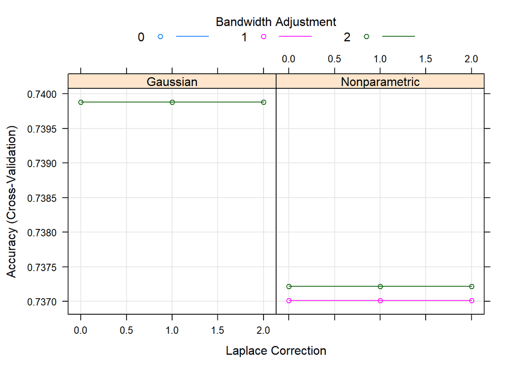

- Una vez hecho esto, pasamos a predecir usando el modelo construido y los datos de test.

*Mostramos la matriz de confusion.

```
## Confusion Matrix and Statistics
##
##           Reference
## Prediction   F   V
##          F 551 249
##          V 298 998
##
##                Accuracy : 0.739
##                  95% CI : (0.7197, 0.7577)
##     No Information Rate : 0.5949
##     P-Value [Acc > NIR] : < 2e-16
##
##                   Kappa : 0.4535
##  Mcnemar's Test P-Value : 0.04014
##
##             Sensitivity : 0.6490
##             Specificity : 0.8003
##          Pos Pred Value : 0.6887
##          Neg Pred Value : 0.7701
##              Prevalence : 0.4051
##          Detection Rate : 0.2629
##    Detection Prevalence : 0.3817
##       Balanced Accuracy : 0.7247
##
##        'Positive' Class : F
##
```

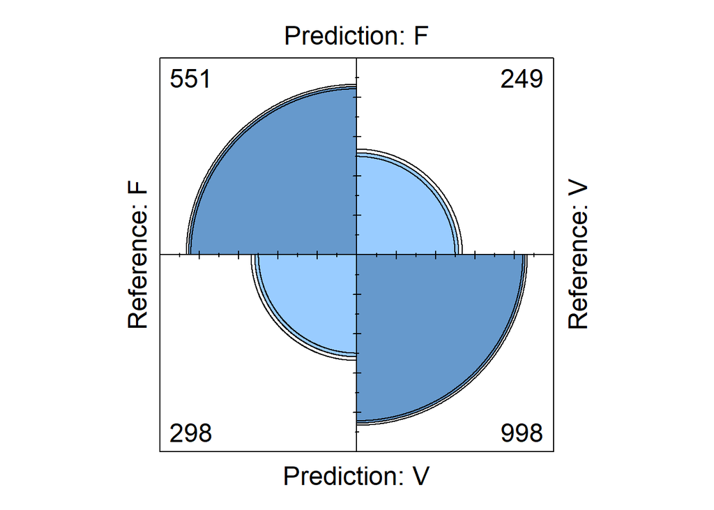

- A continuacion, vamos a utilizar la curva de ROC con los valores de pAUC:

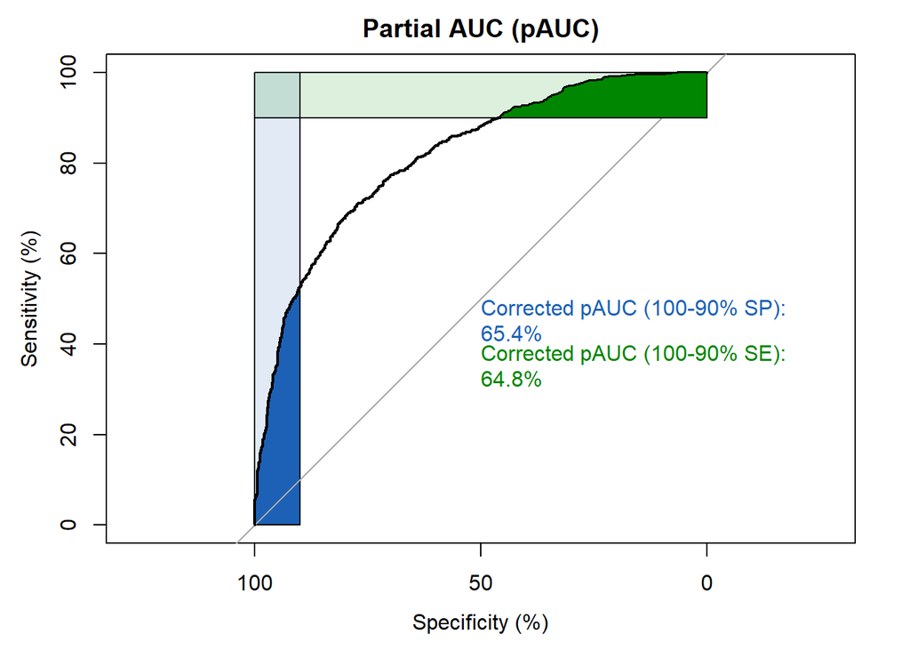

  ## RANDOM FOREST
- Random forest es otra técnica de aprendizaje automático y nace como mejora sustancial de los árboles simples. Combina una cantidad grande de árboles de decisión independientes probados sobre conjuntos de datos aleatorios con igual distribución.
- La fase de aprendizaje consiste en crear una gran cantidad de árboles de decisión independientes. Estos arboles se construyen a partir de los datos de entrada ligeramente modificados. Se modifica el conjunto inicial de partida, de la siguiente forma:
  - Se selecciona aleatoriamente con reemplazamiento un porcentaje de datos de la muestra total.
- Es habitual incluir un segundo nivel aleatoriedad, esta vez afectando los atributos:
  - En cada nodo, al seleccionar la partición óptima, tenemos en cuenta sólo una porción de los atributos, elegidos al azar en cada ocasión.
- Una vez que se tienen muchos árboles -500 por ejemplo- la fase de clasificación se lleva a cabo de la siguiente manera:
  - Cada árbol se evalúa de forma independiente y la predicción del bosque será la media de los 500 árboles. La proporción de árboles que toman una misma respuesta se interpreta como la probabilidad de la misma.
- El modelo de Random Forest tambien lo construiremos con los mismos datos de entrenamiento que utilizamos en la regresion logistica.

```
##
## Call:
##  randomForest(formula = outcome ~ ., data = train, ntree = 500)
##                Type of random forest: classification
##                      Number of trees: 500
## No. of variables tried at each split: 3
##
##         OOB estimate of  error rate: 23.56%
## Confusion matrix:
##      F    V class.error
## F 1265  715   0.3611111
## V  437 2473   0.1501718
```

```
## mtry = 1  OOB error = 25.13%
## Searching left ...
## Searching right ...
## mtry = 2     OOB error = 23.39%
## 0.06916192 0.01
## mtry = 4     OOB error = 23.87%
## -0.0201049 0.01
```

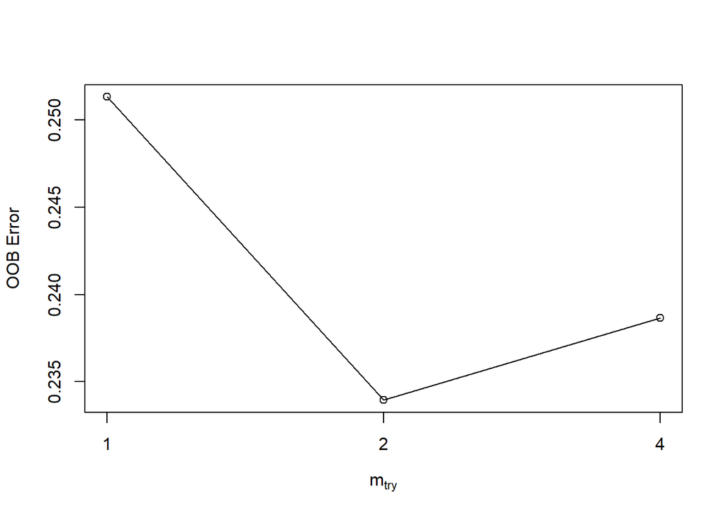

```
##       mtry  OOBError
## 1.OOB    1 0.2513292
## 2.OOB    2 0.2339468
## 4.OOB    4 0.2386503
```

- Utilizamos el siguiente valor como “mtry”.

```
## [1] 2
```

[output not shown]

- Despues de construir el modelo, vamos a utilizar los datos de test para predecirlo. Comprobaremos una vez mas el ajuste de este.

```
## Confusion Matrix and Statistics
##
##           Reference
## Prediction    F    V
##          F  525  153
##          V  324 1094
##
##                Accuracy : 0.7724
##                  95% CI : (0.7539, 0.7902)
##     No Information Rate : 0.5949
##     P-Value [Acc > NIR] : < 2.2e-16
##
##                   Kappa : 0.5121
##  Mcnemar's Test P-Value : 7.04e-15
##
##             Sensitivity : 0.6184
##             Specificity : 0.8773
##          Pos Pred Value : 0.7743
##          Neg Pred Value : 0.7715
##              Prevalence : 0.4051
##          Detection Rate : 0.2505
##    Detection Prevalence : 0.3235
##       Balanced Accuracy : 0.7478
##
##        'Positive' Class : F
##
```

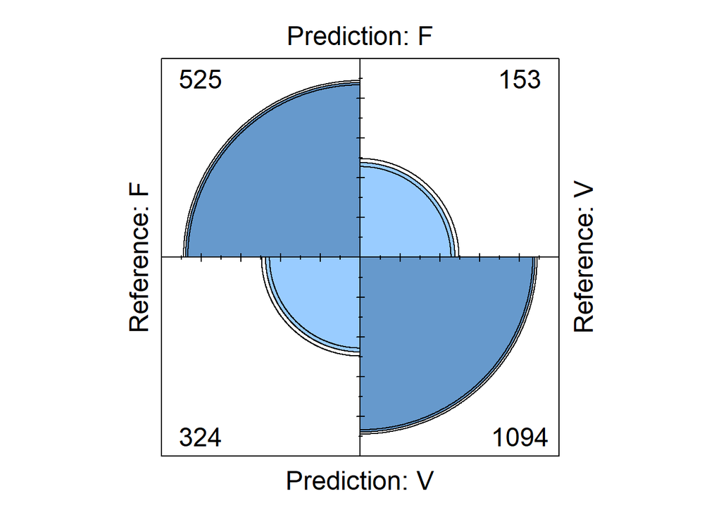

- A continuacion, vamos a utilizar la curva de ROC con los valores de pAUC:

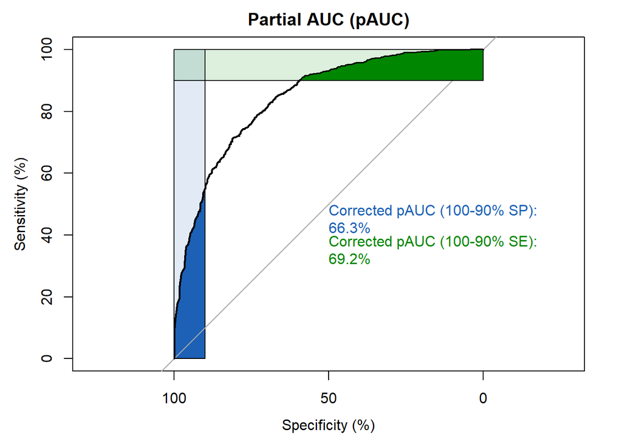

## Adaboost

- El algoritmo AdaBoost propone entrenar iterativamente una serie de clasificadores base, de tal modo que cada nuevo clasificador preste mayor atención a los datos clasificados erróneamente por los clasificadores anteriores, y combinarlos de tal modo que se obtenga un clasificador con elevadas prestaciones.
- Las caracteristicas que lo convierten en un buen metodo son: su capacidad de evadir el **overfitting** y su menor porcentaje de error a cambio de tener un error mayor durante el entrenamiento.
- En primer lugar vamos a utilizar el paquete de “caret” con el objetivo de encontrar el modelo optimo usando adaboost. Aplicaremos la validación cruzada.

```
## Boosted Classification Trees
##
## 4890 samples
##   13 predictor
##    2 classes: 'F', 'V'
##
## No pre-processing
## Resampling: Cross-Validated (10 fold)
## Summary of sample sizes: 4401, 4401, 4401, 4401, 4401, 4401, ...
## Resampling results across tuning parameters:
##
##   maxdepth  iter  Accuracy   Kappa
##   1          50   0.7421268  0.4315823
##   1         100   0.7523517  0.4623808
##   1         150   0.7588957  0.4800449
##   2          50   0.7603272  0.4891654
##   2         100   0.7672802  0.5062127
##   2         150   0.7674847  0.5095219
##   3          50   0.7685072  0.5052091
##   3         100   0.7687117  0.5095332
##   3         150   0.7691207  0.5119779
##
## Tuning parameter 'nu' was held constant at a value of 0.1
## Accuracy was used to select the optimal model using the largest value.
## The final values used for the model were iter = 150, maxdepth = 3 and nu
##  = 0.1.
```

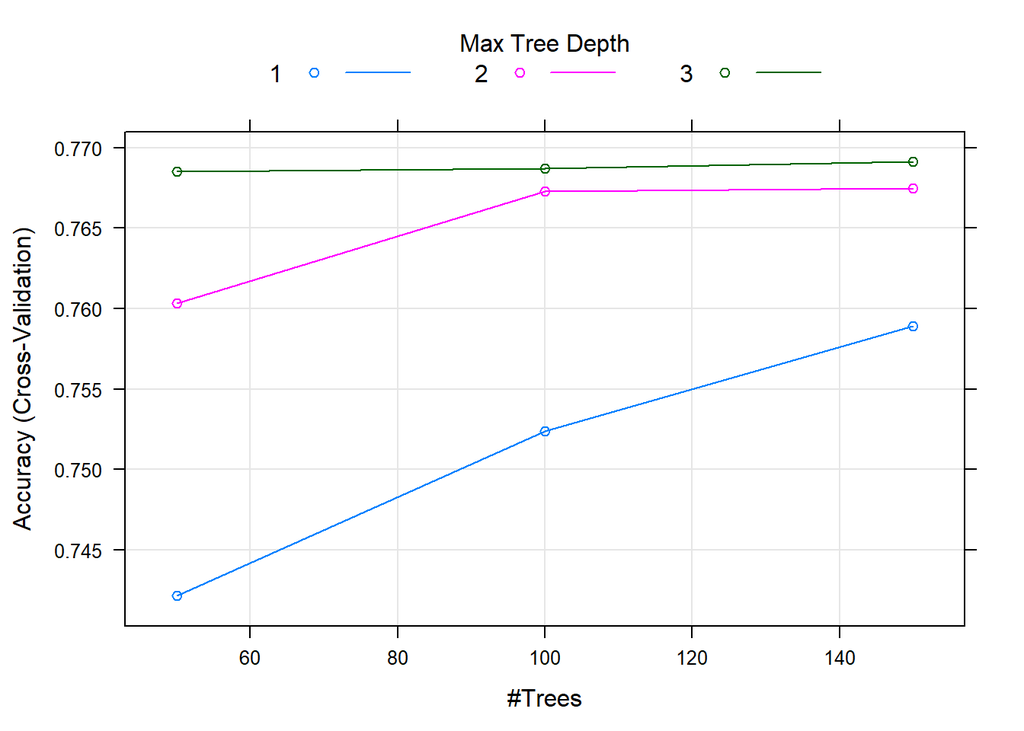

```
## Call:
## ada(outcome ~ ., data = train, iter = 141, nu = 0.3, control = rpart.control(maxdepth = 1))
##
## Loss: exponential Method: discrete   Iteration: 141
##
## Final Confusion Matrix for Data:
##           Final Prediction
## True value    F    V
##          F 1258  722
##          V  389 2521
##
## Train Error: 0.227
##
## Out-Of-Bag Error:  0.231  iteration= 132
##
## Additional Estimates of number of iterations:
##
## train.err1 train.kap1
##        116        140
```

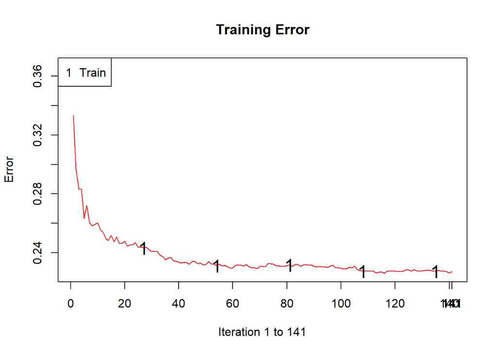

- Despues de construir el modelo con los datos de entrenamiento y habiendo entrenado el modelo construido con los datos de prueba, obtenemos la matriz de confusion:

```
## Confusion Matrix and Statistics
##
##           Reference
## Prediction    F    V
##          F  533  164
##          V  316 1083
##
##                Accuracy : 0.771
##                  95% CI : (0.7524, 0.7888)
##     No Information Rate : 0.5949
##     P-Value [Acc > NIR] : < 2.2e-16
##
##                   Kappa : 0.5109
##  Mcnemar's Test P-Value : 5.495e-12
##
##             Sensitivity : 0.6278
##             Specificity : 0.8685
##          Pos Pred Value : 0.7647
##          Neg Pred Value : 0.7741
##              Prevalence : 0.4051
##          Detection Rate : 0.2543
##    Detection Prevalence : 0.3325
##       Balanced Accuracy : 0.7481
##
##        'Positive' Class : F
##
```

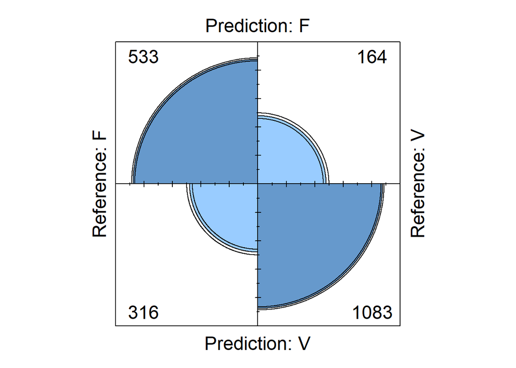

- A continuacion, vamos a utilizar la curva de ROC con los valores de pAUC:

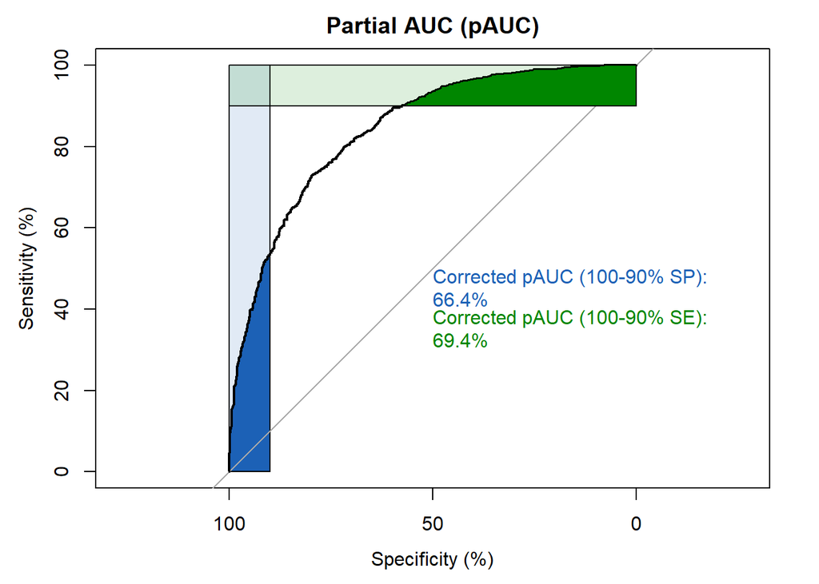

## GBM

- La idea general es obtener una secuencia de árboles (muy) simples, donde cada árbol sucesivo se construye con los residuos de predicción del árbol anterior.
- Una vez generado los arboles uno a uno, se suman las predicciones de los árboles individuales:
- D(x)= dtree1(x) + dtree2(x) + …
- El siguiente árbol de decisiones -dtree3- intenta reducir la diferencia entre la función objetivo f(x) y la predicción del conjunto actual al reconstruir el residuo (dtree1 +dtree2).
- Ademas, el siguiente árbol -dtree3- en el conjunto debe complementarse bien con los árboles existentes y minimizar el error de entrenamiento del conjunto.
- D(x) + dtree3(x) = f(x)
- Para acercarnos a una prediccion sin errores, entrenamos un árbol para reconstruir la diferencia entre la función objetivo y las predicciones actuales de un conjunto, esta diferencia se denomina residuo:
- R(x)= f(x) - D(x)
- Como podemos observar, si el árbol de decisión reconstruye completamente R(x), todo el conjunto daria predicciones sin errores, es decir, predicciones exactas. Esto en la practica nunca sucede.
- Uno de los principales problemas de todos los algoritmos de aprendizaje automático es ‘saber cuándo detenerse’, es decir, cómo evitar que el algoritmo de aprendizaje se ajuste tanto, que probablemente no mejore la validez predictiva del modelo. Este problema también se conoce como el problema del sobreajuste (overfitting).
- Para establecer el limite de estos algoritmos, tenemos en cuenta la iteracion (numero de arboles) en la que se consigue un menor error.
- El modelo de GBM tambien lo construiremos con los mismos datos de entrenamiento que utilizamos en los modelos anteriores.
- A continuacion construimos el modelo automaticamente utilizando el paquete de “caret”, igual que en ejemplos anteriores se ha utilizado la validacion cruzada.

```
## Stochastic Gradient Boosting
##
## 4890 samples
##   13 predictor
##    2 classes: 'F', 'V'
##
## No pre-processing
## Resampling: Cross-Validated (10 fold)
## Summary of sample sizes: 4401, 4401, 4401, 4401, 4401, 4401, ...
## Resampling results across tuning parameters:
##
##   interaction.depth  n.trees  Accuracy   Kappa
##   1                   50      0.7591002  0.4831250
##   1                  100      0.7715746  0.5149340
##   1                  150      0.7707566  0.5148542
##   2                   50      0.7664622  0.5048869
##   2                  100      0.7707566  0.5156113
##   2                  150      0.7687117  0.5114616
##   3                   50      0.7693252  0.5119329
##   3                  100      0.7703476  0.5152530
##   3                  150      0.7695297  0.5131239
##
## Tuning parameter 'shrinkage' was held constant at a value of 0.1
##
## Tuning parameter 'n.minobsinnode' was held constant at a value of 10
## Accuracy was used to select the optimal model using the largest value.
## The final values used for the model were n.trees = 100,
##  interaction.depth = 1, shrinkage = 0.1 and n.minobsinnode = 10.
```

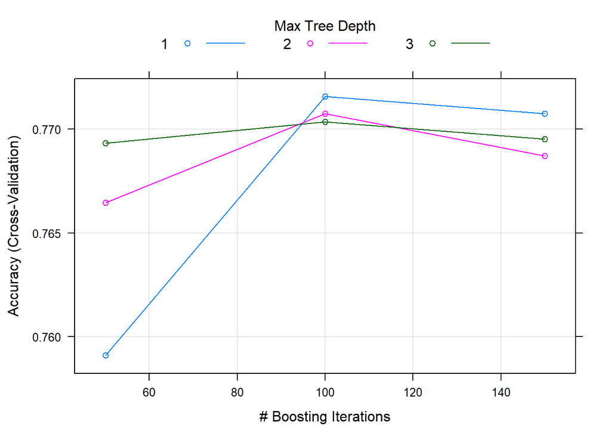

- Vemos que al construir al construir el modelo automaticamente, se utilizan los siguientes valores:
- n.trees = 100. Numero de iteraciones.
- shrinkage = 0.1.Es el ratio de aprendizaje. Simboliza la velocidad a la que se adapta el algoritmo.
- interaction.depth = 1. Este parametro es la complejidad del arbol.
- n.minobsinnode = 10. Es el número mínimo de muestras del conjunto de entrenamiento para que un nodo comience a dividirse.
- Tambien podemos observar en el grafico es que la mejor precision se consigue con una iteracion de 100.
- Vamos a construir otro modelo utilizando fuerza bruta. El objetivo es obtener una mejor precision jugando con los parametros ya vistos para este modelo anteriormente.
- Para ello:
- Iteramos la variable n.trees de 1 a 200 aumentando 10.
- Iteramos la variable interaction.depth de 1 a 5 aumentando 1.
- Iteramos la variable shrinkage de 0.1 a 0.4 aumentando 0.1.
- Iteramos la variable n.minobsinnode de 1 a 15 aumentando 1.
- Utilizando esta configuracion, se ha obtenido resultados similares en la precision.
- Después de construir el modelo, vamos a predecir utilizando los datos de test, con el objetivo de obtener la precision de este.

```
## Confusion Matrix and Statistics
##
##           Reference
## Prediction    F    V
##          F  538  169
##          V  311 1078
##
##                Accuracy : 0.771
##                  95% CI : (0.7524, 0.7888)
##     No Information Rate : 0.5949
##     P-Value [Acc > NIR] : < 2.2e-16
##
##                   Kappa : 0.5118
##  Mcnemar's Test P-Value : 1.229e-10
##
##             Sensitivity : 0.6337
##             Specificity : 0.8645
##          Pos Pred Value : 0.7610
##          Neg Pred Value : 0.7761
##              Prevalence : 0.4051
##          Detection Rate : 0.2567
##    Detection Prevalence : 0.3373
##       Balanced Accuracy : 0.7491
##
##        'Positive' Class : F
##
```

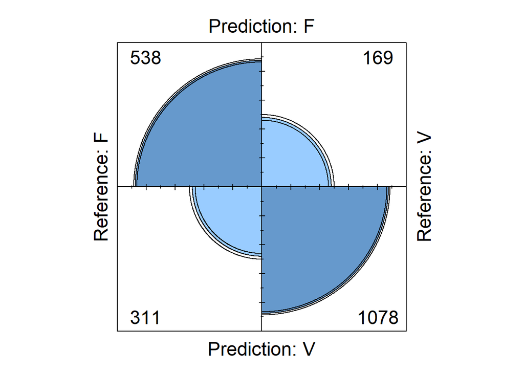

- A continuacion, vamos a utilizar la curva de ROC con los valores de pAUC:

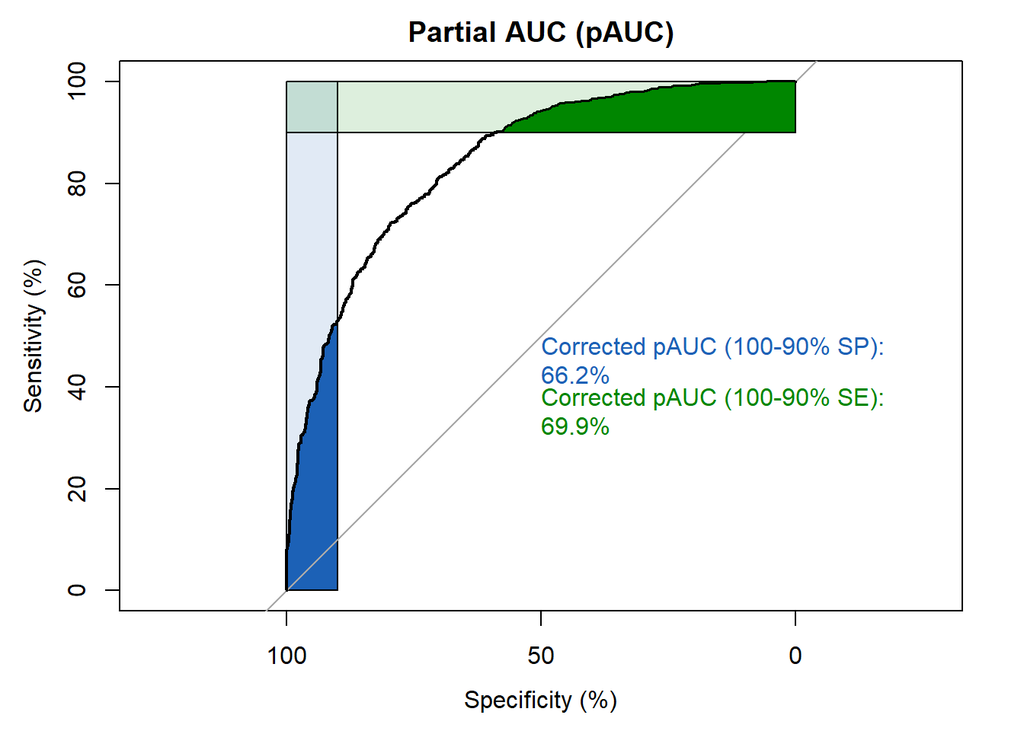

## XGBOOST

- XGBoost es la abreviatura de ‘Extreme Gradient Boosting’. Esta basado en en el modelo original GBM (ya estudiado anteriormente).
- A continuacion se muestran algunas de las ventajas de XGBOOST frente GBM: +Regularizacion: La implementacion de GBM no tiene regularizacion, lo que provoca que XGBOOST reduzca el sobreajuste.
  - Procesammiento paralelo: XGBoost implementa el procesamiento paralelo y es sorprendentemente más rápido en comparación con GBM.
  - Mayor flexibilidad: XGBoost permite a los usuarios definir objetivos de optimización personalizados y criterios de evaluación.
  - Manejo de valores perdidos: XGBoost tiene una rutina incorporada para manejar los valores perdidos.
  - Poda: El algoritmo GBM dejaría de dividir un nodo cuando encuentre una pérdida negativa en una división. Por lo tanto XGBoost es mas codicioso. XGBoost por otro lado hace divisiones hasta la **max_depth** especificada y luego comienza a podar el árbol hacia atrás y a eliminar divisiones de las cuales no hay ganancia positiva.
  - Incorpora Cross-Validation: XGBoost permite al usuario ejecutar una validación cruzada en cada iteración del proceso de “boosting” y, por lo tanto, es fácil obtener el número óptimo de iteraciones de “boosting” en una sola ejecución. Con GBM tenemos que ejecutar una búsqueda en cuadrícula y solo se pueden probar valores limitados.
- Igual que con los modelos construidos con anterioridad, vamos a volver a utilizar “caret” para la validacion cruzada, ademas utilizaremos los siguientes parametros de ajuste para XGBoost que nos ofrece el paquete “xgbtree”:
  - nrounds:Es el número de iteraciones que el modelo ejecuta antes de que se detenga. Con el valor más alto del modelo nrounds tomará más tiempo y viceversa.
  - max_depth (Profundidad máxima del árbol):Un valor alto de max_depth creará árboles más profundos, es decir, creará un modelo más complejo. Un valor más alto de max_depth puede crear un ajuste excesivo y un valor inferior de max_depth puede crear un ajuste insuficiente. Todo depende de los datos disponibles.
  - eta (Shrinkage): Con un valor alto, el modelo funcionará más rápido y viceversa. Con un “eta” más alto y un menor “round”, el modelo tardará menos tiempo en ejecutarse. Con un “eta” menor y un modelo de “nround” más alto tomará más tiempo.
  - gamma (reducción de pérdida mínima): Para crear una partición adicional en un nodo hoja del árbol Se requiere una reducción de pérdida mínima.
  - colsample_bytree (proporción de columnas de la submuestra): Se escogen aleatoriamente columnas de entre todas las columnas o variables durante el proceso de construccion del arbol. Es similar al parametro de “mtry” de los “Random Forest”. Un valor alto puede crear un ajuste excesivo (overfitting) y un valor pequeño puede crear un ajuste insuficiente.
  - min_child_weight (suma mínima del peso de la instancia): Si el paso de la partición del árbol da como resultado un nodo hoja con la suma del peso de la instancia menor que min_child_weight, entonces el proceso de construcción dejará de particionar más.

```
## eXtreme Gradient Boosting
##
## 4890 samples
##   13 predictor
##    2 classes: 'F', 'V'
##
## No pre-processing
## Resampling: Cross-Validated (10 fold)
## Summary of sample sizes: 4401, 4401, 4401, 4401, 4401, 4401, ...
## Resampling results across tuning parameters:
##
##   max_depth  colsample_bytree  Accuracy   Kappa
##   3          0.5               0.7691207  0.5103336
##   3          0.7               0.7697342  0.5112361
##   6          0.5               0.7666667  0.5055645
##   6          0.7               0.7613497  0.4938099
##
## Tuning parameter 'nrounds' was held constant at a value of 100
##
## Tuning parameter 'min_child_weight' was held constant at a value of
##  2
## Tuning parameter 'subsample' was held constant at a value of 1
## Accuracy was used to select the optimal model using the largest value.
## The final values used for the model were nrounds = 100, max_depth = 3,
##  eta = 0.1, gamma = 1, colsample_bytree = 0.7, min_child_weight = 2
##  and subsample = 1.
```

- Ahora predecimos

```
## Confusion Matrix and Statistics
##
##           Reference
## Prediction    F    V
##          F  551  177
##          V  298 1070
##
##                Accuracy : 0.7734
##                  95% CI : (0.7548, 0.7911)
##     No Information Rate : 0.5949
##     P-Value [Acc > NIR] : < 2.2e-16
##
##                   Kappa : 0.5189
##  Mcnemar's Test P-Value : 3.671e-08
##
##             Sensitivity : 0.6490
##             Specificity : 0.8581
##          Pos Pred Value : 0.7569
##          Neg Pred Value : 0.7822
##              Prevalence : 0.4051
##          Detection Rate : 0.2629
##    Detection Prevalence : 0.3473
##       Balanced Accuracy : 0.7535
##
##        'Positive' Class : F
##
```

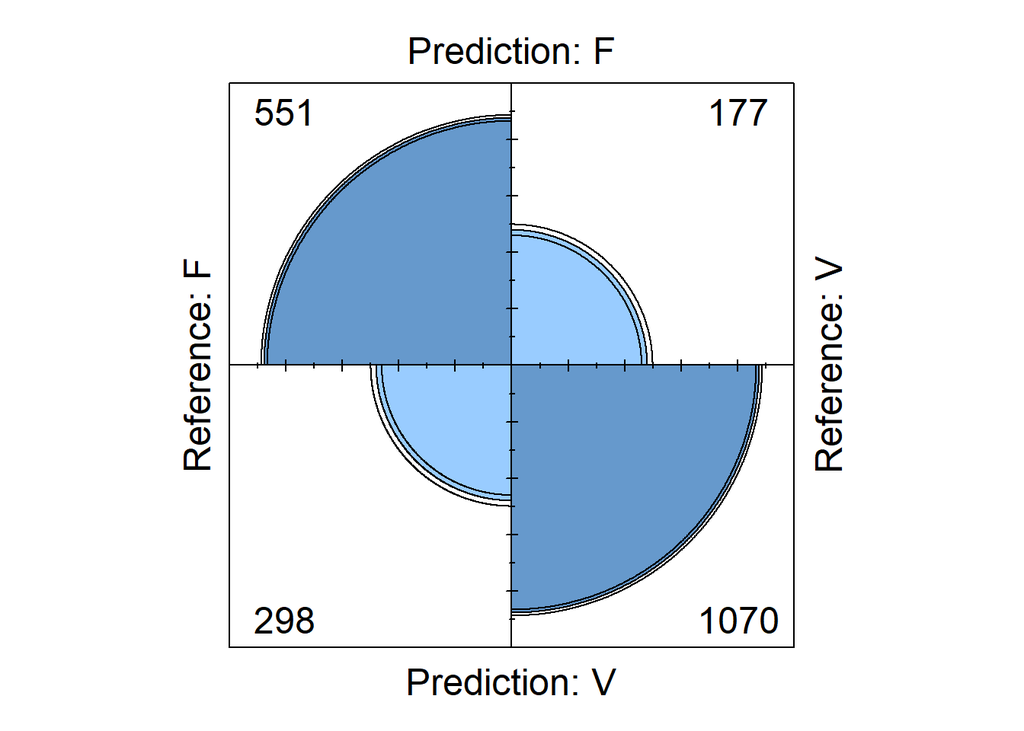

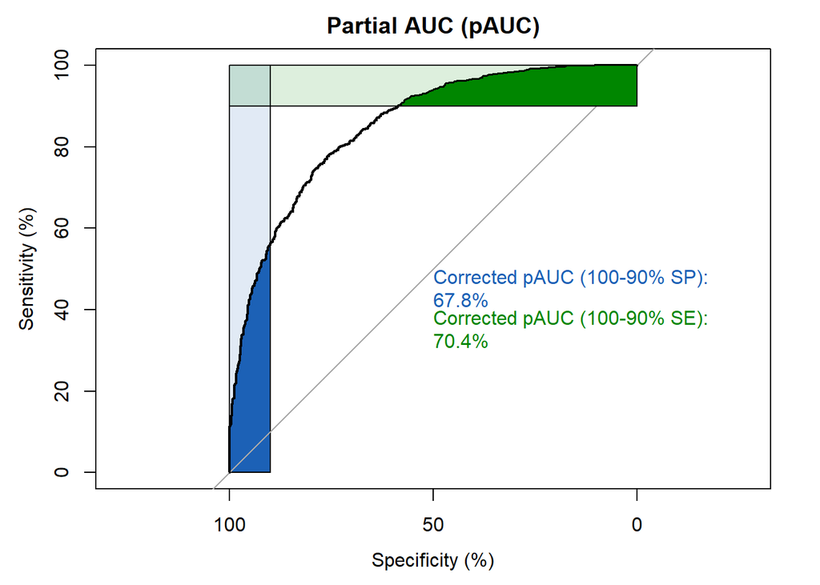

## Redes de neuronas

- Las redes neuronales son sistemas computacionales de aprendizaje basados en el funcionamiento de las redes neuronales biologicas presentes en el cerebro de los animales.
- Estas redes estan construidas a partir de una serie de nodos llamados “neuronas” que se organizan en forma de capas. Existe una capa de entrada, una capa de salida y al menos una capa intermedia o capa “oculta”.
- La capa de entrada debe tener tantas neuronas como variables de entrada tenga el sistema que se va a modelar. La capa de salida debe tener tantas neuronas como variables que estemos intentando predecir, en nuestro caso solo una.
- En cuanto a las capas ocultas, sus neuronas realizan transformaciones no lineales sobre la informacion que los atraviesa mediante una funcion de activacion. Las salidas de estas funciones de activacion suelen variar entre 0 y 1. Estas neuronas se activan o no dependiendo de si la informacion que entra en estas neuronas Si la informacion que entra en esta neurona supera un valor umbral.
- Las tareas de estas neuronas “ocultas” es realizar una suma ponderada de todas las entradas que tiene y aplicarle una funcion de activacion para posteriormente pasar este valor a las neuronas de la siguiente capa, que a su vez repetiran el proceso.
- En primer lugar, antes de comenzar con la construccion del modelo de redes neuronales, es necesario normalizar los datos.

## Mejorar la precision de nuestro modelo

- Para poder obtener las mejores prediciones (precision) con nuestro modelo de redes neuronales, deberemos tener en cuenta aspectos como:
- *Numero de capas ocultas*.
- *Numero de neuronas por capa oculta:* Si se usa una cantidad inadecuada de neuronas, la red no podrá modelar datos complejos y el ajuste resultante será deficiente. Si se utilizan demasiadas neuronas, el tiempo de entrenamiento puede ser excesivamente largo y, lo que es peor, la red puede sobreajustar los datos.No hay una regla práctica para elegir el número de neuronas, pero puede considerar esta:
  - N es el número de neuronas ocultas.
  - N = 2/3 del tamaño de la capa de entrada, más el tamaño de la capa de salida.
  - N < dos veces el tamaño de la capa de entrada.
- *Funcion de activacion de las capas ocultas:* Cambiar la función de activación puede ser un factor decisivo.Se pueden probar distintas funciones de activacion: sigmoide, tanh y unidades lineales rectificadas.
- *Funcion de activacion de las capas de salida:* Para una sola capa la elección de la función de activación para la capa de salida dependerá de la tarea que realizaremos con la red (es decir, categorización o regresión). Sin embargo, en redes multicapas, generalmente es deseable que las capas ocultas tengan funciones de activación no lineales (por ejemplo, sigmoide, logística o tanh).

### Usando todas las variables

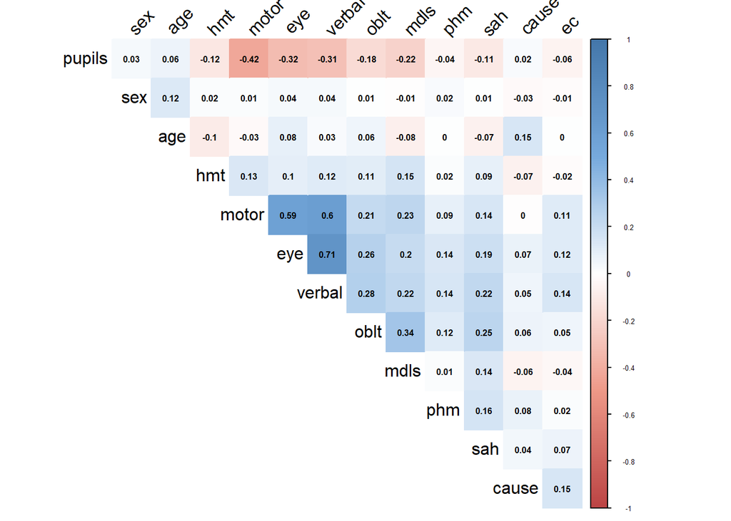

```
## [1] 7 5
```

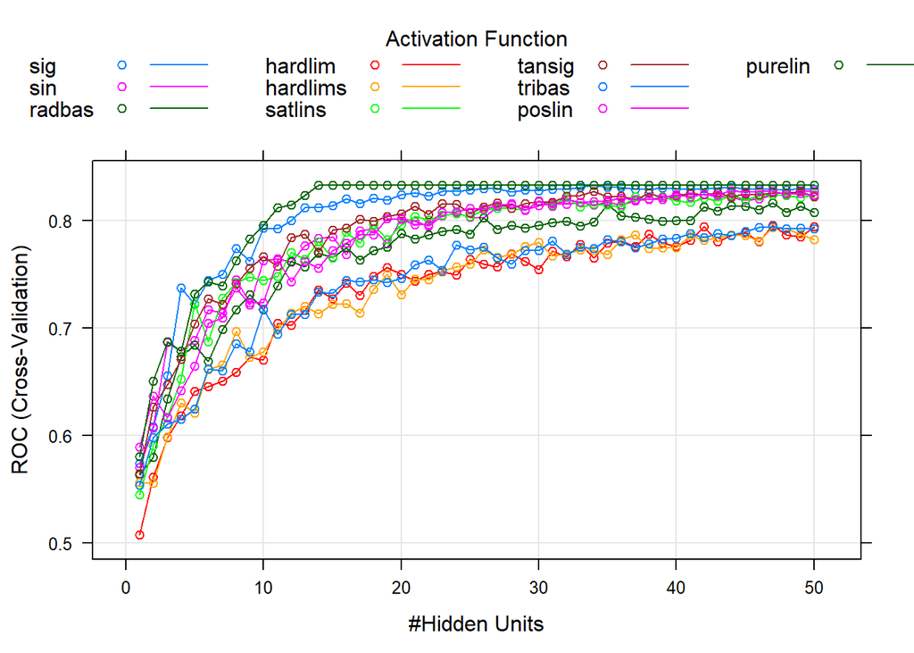

```
## Confusion Matrix and Statistics
##
##           Reference
## Prediction    F    V
##          F  558  200
##          V  291 1047
##
##                Accuracy : 0.7657
##                  95% CI : (0.747, 0.7837)
##     No Information Rate : 0.5949
##     P-Value [Acc > NIR] : < 2.2e-16
##
##                   Kappa : 0.5055
##  Mcnemar's Test P-Value : 4.873e-05
##
##             Sensitivity : 0.6572
##             Specificity : 0.8396
##          Pos Pred Value : 0.7361
##          Neg Pred Value : 0.7825
##              Prevalence : 0.4051
##          Detection Rate : 0.2662
##    Detection Prevalence : 0.3616
##       Balanced Accuracy : 0.7484
##
##        'Positive' Class : F
##
```

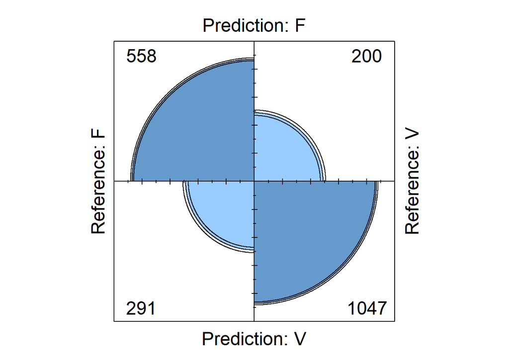

[figure not shown]

### Eliminamos las variables mas correladas: Verbal

- Predecimos

```
## Confusion Matrix and Statistics
##
##           Reference
## Prediction    F    V
##          F  546  196
##          V  303 1051
##
##                Accuracy : 0.7619
##                  95% CI : (0.7431, 0.78)
##     No Information Rate : 0.5949
##     P-Value [Acc > NIR] : < 2.2e-16
##
##                   Kappa : 0.4959
##  Mcnemar's Test P-Value : 2.083e-06
##
##             Sensitivity : 0.6431
##             Specificity : 0.8428
##          Pos Pred Value : 0.7358
##          Neg Pred Value : 0.7762
##              Prevalence : 0.4051
##          Detection Rate : 0.2605
##    Detection Prevalence : 0.3540
##       Balanced Accuracy : 0.7430
##
##        'Positive' Class : F
##
```

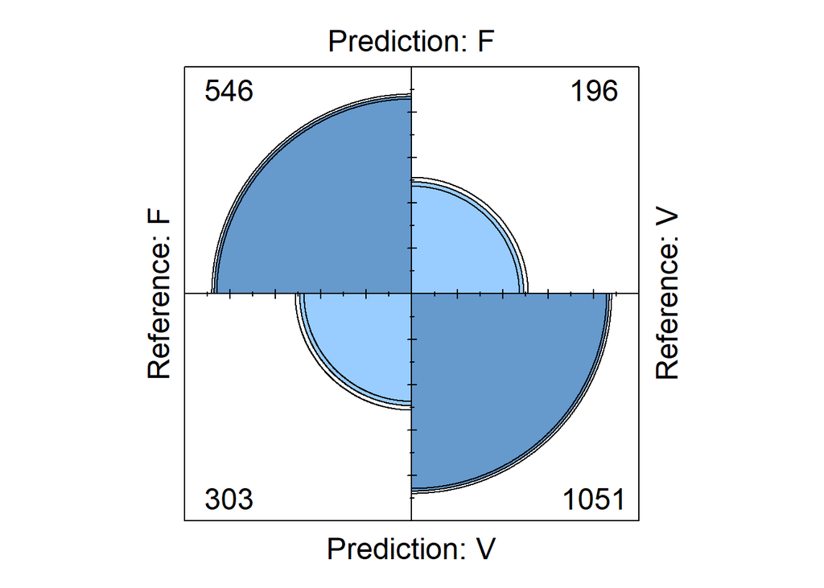

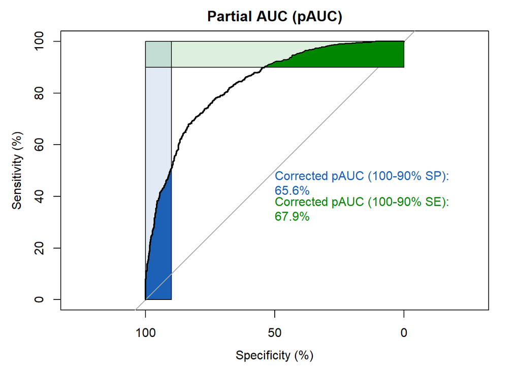

## VALIDACION DE MODELOS

### Comparación de modelos usando el AUCsp y AUCse

[figure not shown]

### Comparación de modelos usando la precisión.

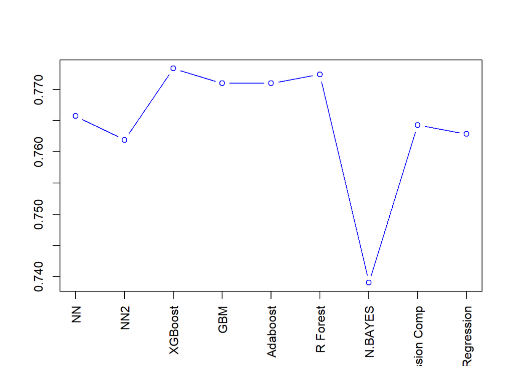